# Cereal Market

## 3.4 Multi-variate Graphical

### 3.4.1 Categorical ads and promo/company

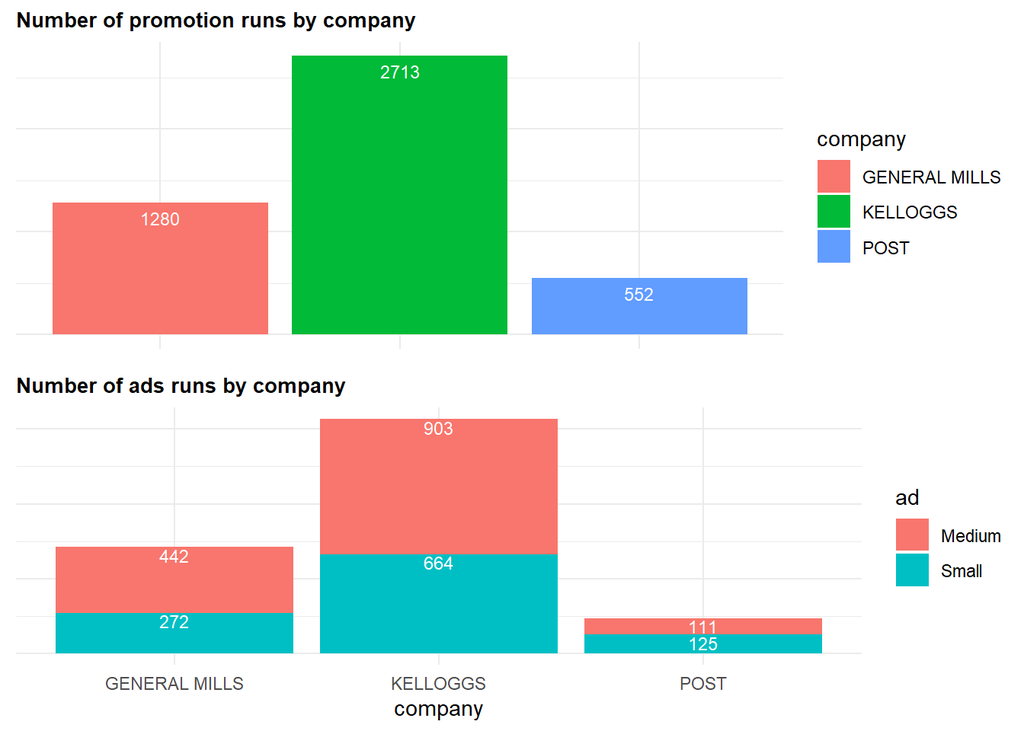

```r
promo_yes <- subset(mtp, promo == "Yes")
ad_AB <- subset(mtp, ad == "Medium" | ad == "Small")

grid.arrange(
  promo_yes %>%
  ggplot(mapping = aes(x = company, fill = company)) +
  geom_bar() +
  theme_minimal() +
  geom_text(stat = 'count', aes(label = ..count..), vjust = 1.6, color = "white", size = 3) +
  theme(plot.title = element_text(family = "Trebuchet MS", face="bold",size=10, hjust=0), axis.title.y = element_blank(), axis.text.y = element_blank(), axis.ticks.y = element_blank(),axis.title.x = element_blank(), axis.text.x = element_blank(), axis.ticks.x = element_blank()) +
  ggtitle("Number of promotion runs by company"),

  # Using this graph for memo, revised version at the end
  ad_AB %>%
  ggplot(mapping = aes(x = company, fill = ad)) +
  geom_bar() +
  theme_minimal() +
  geom_text(stat = 'count', aes(label = ..count..), vjust = 1.1, color = "white", size = 3, position = "stack") +
  theme(plot.title = element_text(family = "Trebuchet MS", face="bold",size=10, hjust=0), axis.title.y = element_blank(), axis.text.y = element_blank(), axis.ticks.y = element_blank()) +
  ggtitle("Number of ads runs by company")

)
```

- Comments:
  - Kelloggs runs almost double ads and promotions than General Mills. This could be a reason why their revenue and market share is high.
  - For the amount of ads/promos General Mills runs, they still stand as a good competitor.
- Questions:
  - How does Promotion and ads affect revenue and market share?

### 3.4.2 Categorical company/qrt

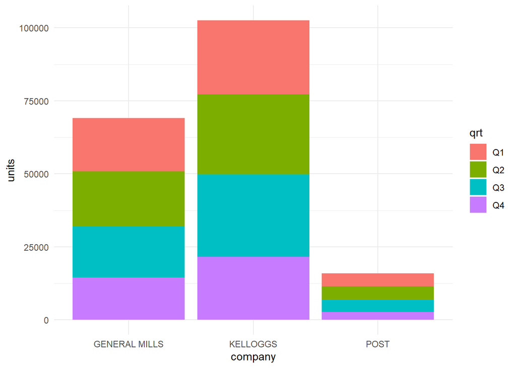

```r
ggplot(data = mtp, mapping = aes(x = company, y = units, fill = qrt)) +
  geom_bar(stat = "identity") +
  theme_minimal()
```

- Comments:
  - Kelloggs exceeds the amount of units sold in all quarters.
- Questions:
  - What are the most popular flavors for General Mills and Kelloggs in terms of units?
  - How is the flavor differ the price/volume

### 3.4.3 Quantitative

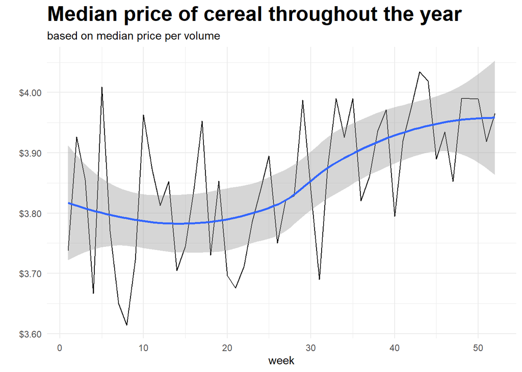

```r
mtp %>%
  group_by(week_th) %>%
  summarize(med_price = median(price/volume)) %>%
  ggplot(mapping = aes(x = week_th, y = med_price)) +
  theme_minimal() +
  labs(title = "Median price of cereal throughout the year", subtitle = "based on median price per volume", x = "week", y = "") +
  theme(plot.title = element_text(family = "Trebuchet MS", face="bold", size=20, hjust=0)) +
  scale_y_continuous(labels = dollar) +
  geom_line() +
  geom_smooth()
```

- Median Price/volume seems to have a slightly positive slope thoughtout the year
  - Very volatile among the weeks
- Questions:
  - Does promotion and ads affect this graph? If so, prices increase dramatically right after.

### 3.4.4 Categorical and Quantitative

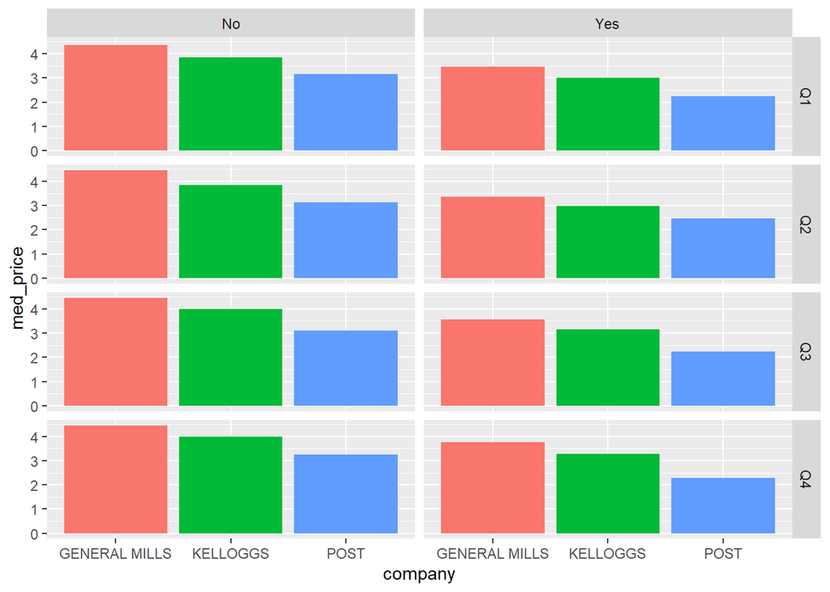

```r
mtp %>%
  group_by(qrt, company, promo) %>%
  summarize(med_price = median(price/volume)) %>%
  ggplot(mapping = aes(x = company, y = med_price, fill = company)) +
  geom_bar(stat = "identity") +
  theme(legend.position = "None") +
  facet_grid(qrt ~ promo)
```

- Comments:
  - Prices are constant among each company by quarter. This includes the distinct variable on whethere there is a promo or not.
  - General Mills seems to contain a higher price per volume, with and without promo.
- Question:
  - Could this be why customers purchase more Kelloggs than General Mills?

# 4 - Detailed EDA

## 4.1 Is there a seasonality trend among specific flavors?

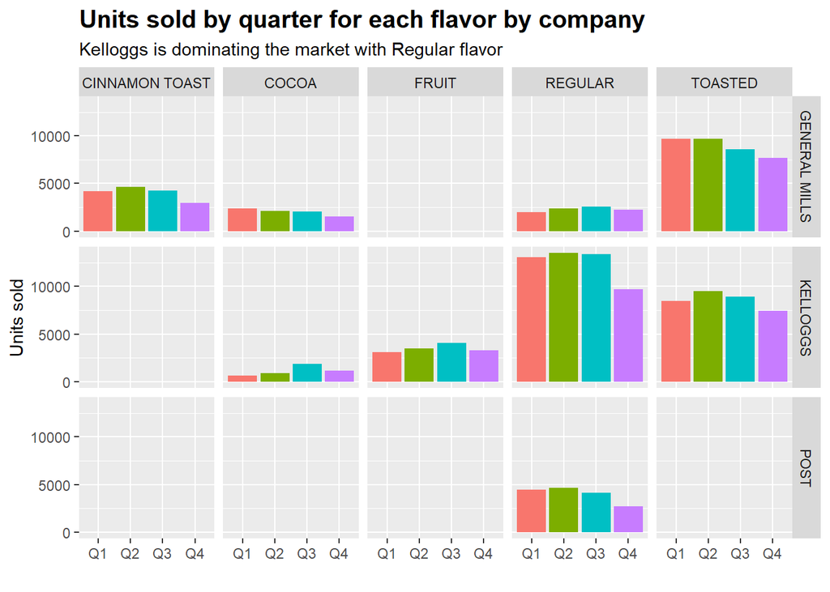

```r
# Use this graph for memo
mtp %>%
  group_by(qrt, company, flavor) %>%
  ggplot(mapping = aes(x = qrt, y = units, fill = qrt)) +
  geom_bar(stat = "identity") +
  facet_grid(company ~ flavor) +
  theme(plot.title = element_text(family = "Trebuchet MS", face="bold",size=15, hjust=0),legend.position = "none") +
  labs(x="", y="Units sold", title = "Units sold by quarter for each flavor by company", subtitle = "Kelloggs is dominating the market with Regular flavor")
```

```r
ggsave("unitssold.png")
```

- Comments:
  - General Mills does great all year round.
  - Cocoa Flavor does well all four quarters, however there is a significant drop on the fourth qtr.
  - High competition on toasted with Kelloggs. GM leads the first quarter, then Kelloggs catches up second quarter.
  - Not doing well against our competitors on regular flavor.
- Question: Throughout the year, there is not an extreme fluctuation for all flavors, except regular. During the fourth quarter, we see a drop in cereal consumption for all companies. Is this because of a holiday? Or is there a more preferred type of breakfast during this time of the year.